# Animal Shelter Outcome Prediction

Yvonne Kirschler

2025-04-15

# 1 Introduction

This report is part of the **HarvardX Data Science Capstone – Choose Your Own** module.  
It explores the challenge of predicting animal outcomes (e.g. Adoption, Transfer, Euthanasia)  
at the **Austin Animal Center**, using available intake data.

The dataset contains over 79,000 records and includes features such as:

- animal type
- intake type
- intake condition
- sex upon intake

**Goal:** Predict the `outcome_type` using machine learning  
**Main challenge:** High class imbalance (e.g., ~42% Adoption)

# 2 Methods

## 2.1 Data loading

```r
data <- read_csv("data/archive/aac_intakes_outcomes.csv")
glimpse(data)
```

```
## Rows: 79,672
## Columns: 41
## $ age_upon_outcome           <chr> "10 years", "7 years", "6 years", "10 years…
## $ animal_id_outcome          <chr> "A006100", "A006100", "A006100", "A047759",…
## $ date_of_birth              <dttm> 2007-07-09, 2007-07-09, 2007-07-09, 2004-0…
## $ outcome_subtype            <chr> NA, NA, NA, "Partner", NA, NA, NA, NA, NA, …
## $ outcome_type               <chr> "Return to Owner", "Return to Owner", "Retu…
## $ sex_upon_outcome           <chr> "Neutered Male", "Neutered Male", "Neutered…
## $ `age_upon_outcome_(days)`  <dbl> 3650, 2555, 2190, 3650, 5840, 5475, 5475, 5…
## $ `age_upon_outcome_(years)` <dbl> 10, 7, 6, 10, 16, 15, 15, 15, 15, 18, 16, 1…
## $ age_upon_outcome_age_group <chr> "(7.5, 10.0]", "(5.0, 7.5]", "(5.0, 7.5]", …
## $ outcome_datetime           <dttm> 2017-12-07 14:07:00, 2014-12-20 16:35:00, …
## $ outcome_month              <dbl> 12, 12, 3, 4, 11, 11, 11, 9, 3, 9, 11, 12, …
## $ outcome_year               <dbl> 2017, 2014, 2014, 2014, 2013, 2013, 2014, 2…
## $ outcome_monthyear          <chr> "2017-12", "2014-12", "2014-03", "2014-04",…
```

[output cut: 28 more lines]

## 2.2 Exploratory data analysis

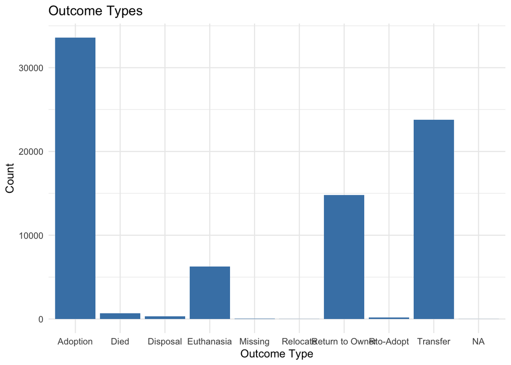

```r
# Outcome distribution
data %>% count(outcome_type) %>%
  ggplot(aes(x = fct_infreq(outcome_type), y = n)) +
  geom_col(fill = "steelblue") +
  labs(title = "Outcome Types", x = "Outcome Type", y = "Count") +
  theme_minimal()
```

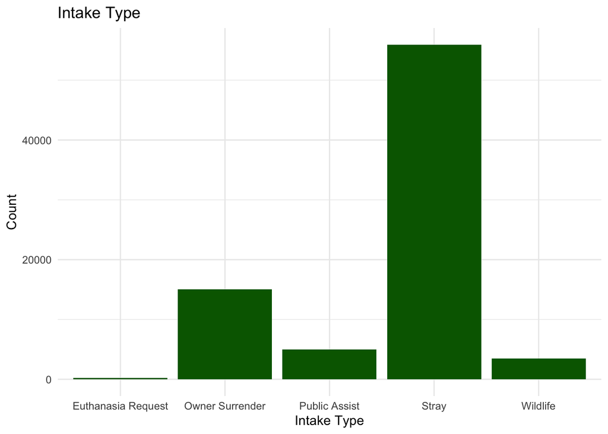

```r
# Intake type distribution
data %>% count(intake_type) %>%
  ggplot(aes(x = fct_infreq(intake_type), y = n)) +
  geom_col(fill = "darkgreen") +
  labs(title = "Intake Type", x = "Intake Type", y = "Count") +
  theme_minimal()
```

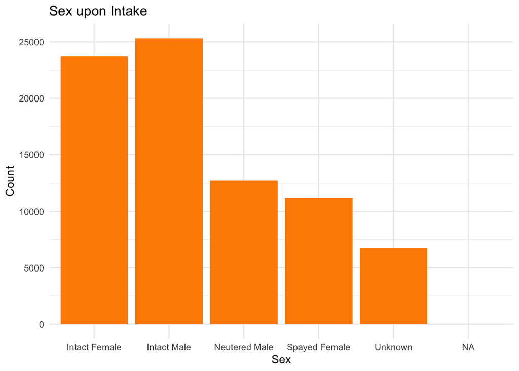

```r
# Sex upon intake
data %>% count(sex_upon_intake) %>%
  ggplot(aes(x = fct_infreq(sex_upon_intake), y = n)) +
  geom_col(fill = "darkorange") +
  labs(title = "Sex upon Intake", x = "Sex", y = "Count") +
  theme_minimal()
```

## 2.3 Data preprocessing

Only variables that are known at the time of intake were selected,  
to simulate a real-time decision support scenario.

```r
data <- data %>%
  filter(!is.na(outcome_type)) %>%
  drop_na(animal_type, intake_type, sex_upon_intake, intake_condition)
```

## 2.4 Train/test split

```r
set.seed(42)
train_index <- createDataPartition(data$outcome_type, p = 0.8, list = FALSE)
train_set <- data[train_index, ]
test_set  <- data[-train_index, ]
```

# 3 Modeling

## 3.1 Baseline model

```r
most_common <- train_set %>%
  count(outcome_type) %>%
  slice_max(n, n = 1) %>%
  pull(outcome_type)

baseline_predictions <- rep(most_common, nrow(test_set))
baseline_accuracy <- mean(baseline_predictions == test_set$outcome_type)
baseline_accuracy
```

```
## [1] 0.421773
```

## 3.2 Random Forest model (5-fold CV)

```r
rf_data <- train_set %>%
  mutate(outcome_type = as.factor(outcome_type)) %>%
  select(outcome_type, animal_type, intake_type, sex_upon_intake, intake_condition)

rf_control <- trainControl(method = "cv", number = 5)

set.seed(42)
rf_model <- train(
  outcome_type ~ .,
  data = rf_data,
  method = "rf",
  trControl = rf_control,
  importance = TRUE
)

rf_predictions <- predict(rf_model, newdata = test_set)

# Align factor levels
combined_levels <- union(levels(rf_predictions), levels(test_set$outcome_type))
rf_predictions <- factor(rf_predictions, levels = combined_levels)
test_set$outcome_type <- factor(test_set$outcome_type, levels = combined_levels)

rf_accuracy <- mean(rf_predictions == test_set$outcome_type)
rf_confusion <- confusionMatrix(rf_predictions, test_set$outcome_type)

rf_accuracy
```

```
## [1] 0.5803616
```

```r
rf_confusion
```

```
## Confusion Matrix and Statistics
##
##                  Reference
## Prediction        Adoption Died Disposal Euthanasia Missing Relocate
##   Adoption            5688   62        4        287       7        0
##   Died                   0    1        0          0       0        0
##   Disposal               0    0        0          0       0        0
##   Euthanasia            90   42       50        773       0        3
##   Missing                0    0        0          0       0        0
##   Relocate               0    0        0          0       0        0
##   Return to Owner      619    6        0         59       1        0
##   Rto-Adopt              0    0        0          0       0        0
##   Transfer             321   27        6        129       1        0
##                  Reference
## Prediction        Return to Owner Rto-Adopt Transfer
##   Adoption                   1027        17     3265
##   Died                          0         0        0
##   Disposal                      0         0        0
##   Euthanasia                   34         0      117
##   Missing                       0         0        0
##   Relocate                      0         0        0
##   Return to Owner            1727        13      322
##   Rto-Adopt                     0         0        0
##   Transfer                    170         5     1055
##
## Overall Statistics
##
##                Accuracy : 0.5804
##                  95% CI : (0.5727, 0.588)
##     No Information Rate : 0.4218
##     P-Value [Acc > NIR] : < 2.2e-16
##
##                   Kappa : 0.3604
##
##  Mcnemar's Test P-Value : NA
##
## Statistics by Class:
##
##                      Class: Adoption Class: Died Class: Disposal
## Sensitivity                   0.8467   7.246e-03        0.000000
```

[output cut: 10 more lines]

```
## Pos Pred Value                 0.69702            NaN             NaN
## Neg Pred Value                 0.96795       0.999435       0.9998117
## Prevalence                     0.07835       0.000565       0.0001883
## Detection Rate                 0.04853       0.000000       0.0000000
## Detection Prevalence           0.06963       0.000000       0.0000000
## Balanced Accuracy              0.79825       0.500000       0.5000000
##                      Class: Return to Owner Class: Rto-Adopt Class: Transfer
## Sensitivity                          0.5838         0.000000         0.22169
## Specificity                          0.9214         1.000000         0.94100
## Pos Pred Value                       0.6287              NaN         0.61552
## Neg Pred Value                       0.9066         0.997803         0.73941
## Prevalence                           0.1857         0.002197         0.29878
## Detection Rate                       0.1084         0.000000         0.06624
## Detection Prevalence                 0.1725         0.000000         0.10761
## Balanced Accuracy                    0.7526         0.500000         0.58134
```

# 4 Results

## 4.1 Accuracy comparison

```r
absolute_improvement <- rf_accuracy - baseline_accuracy
relative_improvement <- absolute_improvement / baseline_accuracy

tibble(
  Baseline = baseline_accuracy,
  RandomForest = rf_accuracy,
  AbsoluteImprovement = absolute_improvement,
  RelativeImprovement = percent(relative_improvement, accuracy = 0.1)
)
```

```
## # A tibble: 1 × 4
##   Baseline RandomForest AbsoluteImprovement RelativeImprovement
##      <dbl>        <dbl>               <dbl> <chr>
## 1    0.422        0.580               0.159 37.6%
```

## 4.2 Variable importance

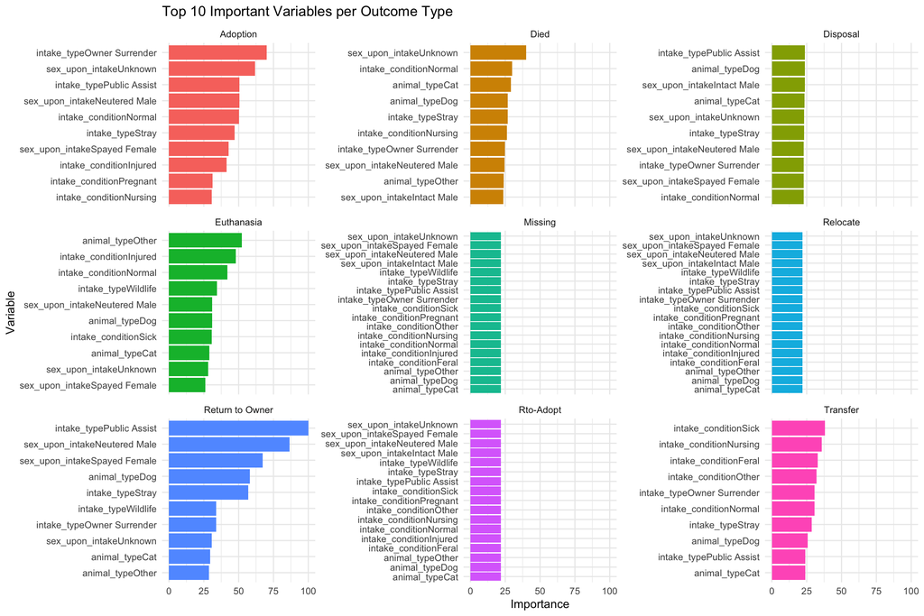

```r
importance_df <- varImp(rf_model)$importance %>%
  rownames_to_column("Variable") %>%
  pivot_longer(-Variable, names_to = "Outcome", values_to = "Importance") %>%
  group_by(Outcome) %>%
  slice_max(order_by = Importance, n = 10)

ggplot(importance_df, aes(x = reorder_within(Variable, Importance, Outcome), y = Importance, fill = Outcome)) +
  geom_col(show.legend = FALSE) +
  facet_wrap(~ Outcome, scales = "free_y") +
  coord_flip() +
  scale_x_reordered() +
  labs(
    title = "Top 10 Important Variables per Outcome Type",
    x = "Variable",
    y = "Importance"
  ) +
  theme_minimal()
```

## 4.3 Model performance visualization

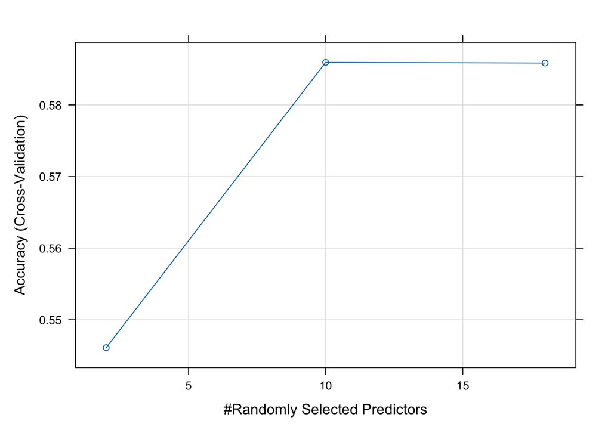

```r
plot(rf_model)
```

# 5 Conclusion

This project explored how to predict animal shelter outcomes using features available at the time of intake.  
Two models were compared:

- **Baseline (majority class):** 0.4218
- **Random Forest (5-fold CV):** 0.5804
- **Relative improvement:** 37.6%

The Random Forest model significantly outperformed the baseline,  
with a relative accuracy improvement of over 37%.  
Top predictors were `intake_type`, `sex_upon_intake`, and `intake_condition`.

# 6 Interpretation

- Stray animals tend to be adopted more often
- Owner-surrendered animals show different outcome trends
- Health-related intake conditions are linked to higher euthanasia or transfer rates
- Neutered/spayed animals may be more adoptable

# 7 Limitations

- Strong class imbalance affects minority classes
- No temporal or behavioral history used
- Model not tuned for hyperparameters beyond `mtry`

# 8 References

- Austin Animal Center Dataset: https://www.kaggle.com/datasets/aaronschlegel/austin-animal-center-shelter-intakes-and-outcomes
- caret R package: https://topepo.github.io/caret/
- randomForest package: https://cran.r-project.org/web/packages/randomForest
- OpenAI (ChatGPT): Supported structure and phrasing; modeling and decisions by Yvonne Kirschler

# 9 Appendix